# My Spotify Liked Songs over time

Author

Ronan Goodman

# Introduction

To do this we will first by gaining access to my Liked songs through the Spotify API, then I will match those with the teacher’s dataset. After some extra steps to ensure proper data prepration, I will be analyzing the data.

(FYI: in the beginning I did not immediately “like” songs after putting them in a playlist, only sporadically would I add them all to my liked songs list. So the dates in the first year do not really make sense)

## Some highlights over the years

*click images for spotify link*

[figure not shown]

Album Cover

[figure not shown]

Album Cover

[figure not shown]

Album Cover

**Indie Rock**  
Strokes - Someday?  
(added March 17th 2021)

**The Classics**  
The Animals - House of The Rising Sun  
(added September 10th 2021)

**2010s Pop**  
The Black Eyed Peas - I Got A Feeling  
(added 14th June 2022)

[figure not shown]

Album Cover

[figure not shown]

Album Cover

[figure not shown]

Album Cover

**Trance Techno**  
NTO - La Clé Des Champs  
(added January 25th 2023)

**Jazzy House (idk)**  
Doctor Rockit - Café de Flore  
(added Augustus 10th 2024)

**Hard Trance (or something)**  
Ascendant Vierge - Influenceur  
(added December 23th 2025)

# Creating the Data Frame

## Spotify’s API

Before I could analysis my Liked Songs, I had to get them into a single data frame. This was done through the Spotify Developer API.

I basically requested my listening data from Spotify using code. I don’t really know how it works, but I just wanted my Liked Songs to do the actual assignment.

Only god (and my brother) knows why it worked.

```r
#lots of packages, better safe then sorry
library(httr)
library(dplyr)
library(purrr)
library(tibble)
library(stringr)
library(readr)
library(lubridate)
library(ggplot2)
library(knitr)


#credentials used for spotify API access

CLIENT_ID     <- "xxxxx"
CLIENT_SECRET <- "xxxxx"
REDIRECT_URI  <- "http://127.0.0.1:1410/"
SCOPE         <- "user-library-read"


#Qauth authorisation

spotify_endpoints <- oauth_endpoint(
  authorize = "https://accounts.spotify.com/authorize",
  access    = "https://accounts.spotify.com/api/token"
)

spotify_app <- oauth_app(
  appname = "spotify-likes-project",
  key     = CLIENT_ID,
  secret  = CLIENT_SECRET,
  redirect_uri = REDIRECT_URI
)

token <- oauth2.0_token(
  endpoint = spotify_endpoints,
  app      = spotify_app,
  scope    = SCOPE,
  cache    = FALSE,
  use_basic_auth = TRUE
)

#Helper: NULL coalesce

`%||%` <- function(a, b) if (is.null(a)) b else a

#getting liked songs, 50 at a time cause of rate limits. took some time to know that i needed this.

sp_get <- function(url, query = list()) {
  if (!exists("token")) stop()
  if (inherits(token, "Token2.0")) token$refresh()

  access <- token$credentials$access_token

  resp <- httr::GET(
    url,
    query = query,
    httr::add_headers(Authorization = paste("Bearer", access))
  )

  httr::stop_for_status(resp)
  httr::content(resp, as = "parsed", type = "application/json")
}

get_all_saved_tracks <- function(limit = 50) {
  offset <- 0
  out <- list()

  repeat {
    dat <- sp_get(
      "https://api.spotify.com/v1/me/tracks",
      query = list(limit = limit, offset = offset)
    )

    items <- dat$items
    if (length(items) == 0) break

    chunk <- tibble(
      added_at    = vapply(items, `[[`, "", "added_at"),
      track_id    = vapply(items, function(x) x$track$id %||% NA_character_, ""),
      track_name  = vapply(items, function(x) x$track$name %||% NA_character_, ""),
      artist_name = vapply(items, function(x) x$track$artists[[1]]$name %||% NA_character_, ""),
      album       = vapply(items, function(x) x$track$album$name %||% NA_character_, ""),
      uri         = vapply(items, function(x) x$track$uri %||% NA_character_, "")
    )

    out[[length(out) + 1]] <- chunk
    offset <- offset + nrow(chunk)

    if (is.null(dat$`next`) || nrow(chunk) < limit) break
  }

  bind_rows(out)
}

liked <- get_all_saved_tracks(limit = 50)


# Save raw liked songs
write_csv(liked, "liked_raw.csv")
saveRDS(liked, "liked_raw.rds")

# Now i have my liked songs in a df called liked_raw
```

## Matching with the Teacher’s Data Frame

The data pull from Spotify gave me lots of track info, but not the audio features that we need. This meant I had to match the “Spotify_data_2022” file we got, with my own data frame.

```r
#loading assignment dataset
songs_2022 <- read_csv("Spotify_data_2022.csv", show_col_types = FALSE)

#column names do not match so i had to change them. I did this by creating 2 new data frames. Perhaps not the most clean option...
liked2 <- liked %>% rename(track = track_name, artist = artist_name)
songs2 <- songs_2022 %>% rename(track = track_name, artist = artists)

#now we have to prepare the data a bit more, to not have conflicts between usage of capital letters in the data frame.
liked2 <- liked2 %>%
  mutate(
    track_clean  = str_to_lower(str_squish(track)),
    artist_clean = str_to_lower(str_squish(artist))
  )

songs2 <- songs2 %>%
  mutate(
    track_clean  = str_to_lower(str_squish(track)),
    artist_clean = str_to_lower(str_squish(artist))
  )

# preparing some more by making sure we dont get duplicates.
songs2_unique <- songs2 %>%
  arrange(track_clean, artist_clean) %>%
  distinct(track_clean, artist_clean, .keep_all = TRUE)

# Add matched flag + bring in teacher columns (where matched)
# So we create a new data frame (yes again), to bring in only the audio charateristics from the teacher dataset that correspond to songs that i have in my data frame.

synt_liked <- liked2 %>%
  mutate(original_order = row_number()) %>%
  left_join(
    songs2_unique %>% mutate(matched_teacher_2022 = TRUE),
    by = c("track_clean", "artist_clean"),
    suffix = c("_liked", "_teacher")
  ) %>%
  mutate(matched_teacher_2022 = if_else(is.na(matched_teacher_2022), FALSE, matched_teacher_2022)) %>%
  arrange(original_order) %>%
  select(-original_order)



# just changing the data frame colomn order so i can more easily analysis what i want to see
liked_songs_analysis <- synt_liked %>%
  select(matched_teacher_2022, track_liked, artist_liked, track_genre, everything())
```

So we have the matched songs data frame now. However, I wanted to just check how many of my Liked Songs are actually in the teacher’s data frame.

```r
print(table(synt_liked$matched_teacher_2022))

write_csv(synt_liked, "synt_liked.csv")
```

[output not shown]

It turns out only 232 songs of the 985 songs are in the teacher’s data frame…  
Something we have to fix for proper analysis of my listening habits over time.

## Manual Retrieval of Audio Characteristics

For this part I systematically went through the synt_liked data frame to select songs that were not matched already. The track_id’s of these songs were put into the online retrieval tool for audio characteristics.

The data frame created from this manual selection consisted of 26 songs, which were selected mainly in the first half of the synt_liked data frame. This was done because in the final half (the older songs) more songs matched with those in the teacher’s data frame.

These selected songs had to then be merged into the Liked Songs data frame, which I (once again, perhaps too many times) recreated.

```r
#Load manual file
manual_audio <- readr::read_csv("manual_analysis_website.csv",
                                show_col_types = FALSE,
                                col_types = readr::cols(.default = readr::col_character()))

#Lowercase column names to match the synth df
names(manual_audio) <- stringr::str_to_lower(names(manual_audio))

#Create clean join key from Song column, as that is the main track colomn in manual csv. This column name is different than the main dataframe.
manual_audio <- manual_audio %>%
  mutate(
    track_clean = stringr::str_to_lower(stringr::str_squish(song))
  )

#convert manual feature columns to numeric, as i got errors before where it did not want to combine the data frames as one was numeric and the other string. Took some time :,(
manual_cols <- setdiff(names(manual_audio), c("song", "track_clean"))

manual_audio <- manual_audio %>%
  mutate(across(all_of(manual_cols), ~ {
    x <- .
    x <- stringr::str_replace_all(x, ",", ".")
    x <- stringr::str_replace_all(x, "[^0-9.\\-]+", "")
    x <- dplyr::na_if(x, "")
    suppressWarnings(as.numeric(x))
  }))

#removing duplicate manual rows by track_clean (keep first)
manual_audio <- manual_audio %>%
  arrange(track_clean) %>%
  distinct(track_clean, .keep_all = TRUE)

#joining onto the working df
tmp <- liked_songs_analysis %>%
  left_join(manual_audio, by = "track_clean", suffix = c("", "_manual"))

#overwriting only where the existing value is NA
cols_to_fill <- intersect(names(liked_songs_analysis), manual_cols)

for (col in cols_to_fill) {
  tmp[[col]] <- dplyr::coalesce(tmp[[col]], tmp[[paste0(col, "_manual")]])
}

#getting rid of  *_manual columns and updating the dataframee
liked_songs_analysis <- tmp %>%
  select(-ends_with("_manual"))
#so now our (i hope) final data frame is called liked_songs_analysis

#written some time later:

#lol i decided i want one more data frame, to only include the songs that have audio charateristics

#now i want to delete all songs that i dont have audio characteristics for for analysis.


audio_vars <- c(
  "danceability",
  "energy",
  "loudness",
  "speechiness",
  "acousticness",
  "instrumentalness",
  "liveness",
  "valence",
  "tempo"
)

LS_short <- liked_songs_analysis %>%
  filter(!if_all(all_of(audio_vars), is.na))

saveRDS(LS_short, "LS_short.rds")
```

# Finally We Can Start Analyzing

## Some Findings While Preparing the Data:

While working with the data I came aross a few things:

1. Songs not matched in teacher’s data set are mainly newly “liked” songs.
   1. These newer songs (what I am listening to now) are mainly house and minimal techno.
   2. Because they did not match they don’t have genre info, which means any analysis of genre will exclude mainly the last year of data.
      1. And the newer house, techno. etc, songs are mainly lesser known, so they don’t have any genre info.
   3. Thus I will not by analyzing by genre itself, even though that would have been better for directly gaining insights.
   4. (This is why I also manually sampled songs from my liked songs list. So i can still analyse the general patterns, but not by actual volume.)
2. Lots of songs in the first few years were added at singular dates, as I started putting all my songs in playlists, into the liked songs list.
   1. Thus (early on) specifc date added (for each song) does not mean much, but the order in which i added still corresponds with listening patterns.
   2. The last few years date added, does correspond directly with when I first started listened to the song and wanted it in a playlist. At which point I also directly added it into the liked songs list.

## Visual of my Data Frame:

Here is what my data frame looks like

```r
#Showcasing 5 random songs from liked songs

library(knitr)

LS_short_5 <- readRDS("LS_short_5.rds")

kable(LS_short_5, digits = 2)
```

| matched_teacher_2022 | track_liked | artist_liked | track_genre | added_at | track_id | album | uri | track_clean | artist_clean | artist_teacher | album_name | track_teacher | popularity | duration_ms | explicit | danceability | energy | key | loudness | mode | speechiness | acousticness | instrumentalness | liveness | valence | tempo | time_signature | song |
| --- | --- | --- | --- | --- | --- | --- | --- | --- | --- | --- | --- | --- | --- | --- | --- | --- | --- | --- | --- | --- | --- | --- | --- | --- | --- | --- | --- | --- |
| TRUE | Crying Lightning | Arctic Monkeys | garage | 2022-05-01T06:45:54Z | 6wVWJl64yoTzU27EI8ep20 | Humbug | spotify:track:6wVWJl64yoTzU27EI8ep20 | crying lightning | arctic monkeys | Arctic Monkeys | Humbug | Crying Lightning | 72 | 224826 | FALSE | 0.50 | 0.88 | 4 | -4.42 | 0 | 0.05 | 0.01 | 0.0 | 0.24 | 0.67 | 106.72 | 4 | NA |
| TRUE | Someday | The Strokes | garage | 2021-03-17T23:15:21Z | 7hm4HTk9encxT0LYC0J6oI | Is This It | spotify:track:7hm4HTk9encxT0LYC0J6oI | someday | the strokes | The Strokes | Is This It | Someday | 70 | 183573 | FALSE | 0.54 | 0.53 | 9 | -7.48 | 1 | 0.03 | 0.00 | 0.0 | 0.34 | 0.67 | 105.97 | 4 | NA |
| TRUE | Dancing Shoes | Arctic Monkeys | garage | 2021-03-17T23:15:44Z | 0hAMkY2kwdXPPDfQ1e3BmJ | Whatever People Say I Am, That’s What I’m Not | spotify:track:0hAMkY2kwdXPPDfQ1e3BmJ | dancing shoes | arctic monkeys | Arctic Monkeys | Whatever People Say I Am, That’s What I’m Not | Dancing Shoes | 63 | 141133 | FALSE | 0.52 | 0.89 | 1 | -4.14 | 1 | 0.05 | 0.00 | 0.0 | 0.34 | 0.85 | 144.50 | 4 | NA |
| TRUE | Move Your Body | Marshall Jefferson | chicago-house | 2025-01-22T13:42:00Z | 3OrcEhLzxv1YX597jGjEI7 | Move Your Body | spotify:track:3OrcEhLzxv1YX597jGjEI7 | move your body | marshall jefferson | Marshall Jefferson | Frankie Knuckles Presents: His Greatest Hits from Trax Records | Move Your Body | 44 | 405760 | FALSE | 0.78 | 0.91 | 4 | -4.15 | 0 | 0.12 | 0.02 | 0.0 | 0.51 | 0.56 | 122.31 | 4 | NA |
| FALSE | Falkor’s Return | Indecorum | NA | 2026-02-06T16:22:00Z | 46a2imjeJLAJAMaJghKyFQ | Sanctus | spotify:track:46a2imjeJLAJAMaJghKyFQ | falkor’s return | indecorum | NA | NA | NA | NA | NA | NA | 0.69 | 0.77 | NA | -8.26 | NA | 0.13 | 0.00 | 0.1 | 0.19 | 0.43 | 149.99 | NA | Falkor’s Return |

## Graphs of Core Audio Characteristics

### Energy

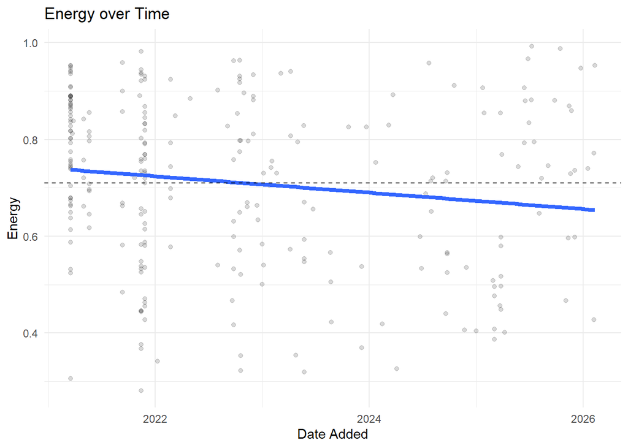

```r
#plot for energy
library(ggplot2)
LS_short <- readRDS("LS_short.rds")
avg_energy <- mean(LS_short$energy, na.rm = TRUE)

ggplot(LS_short, aes(x = added_at, y = energy)) +
  geom_point(alpha = 0.15) +
  geom_smooth(method = "lm", se = FALSE, linewidth = 1.5) +
  geom_hline(yintercept = avg_energy, linetype = "dashed") +
  labs(title = "Energy over Time",
       x = "Date Added",
       y = "Energy") +
  theme_minimal()
```

We see that Energy lowers over time, which could correspond with the change of genres over the years. (Indie/Rock –> House / Minimal Techno)

### Danceability

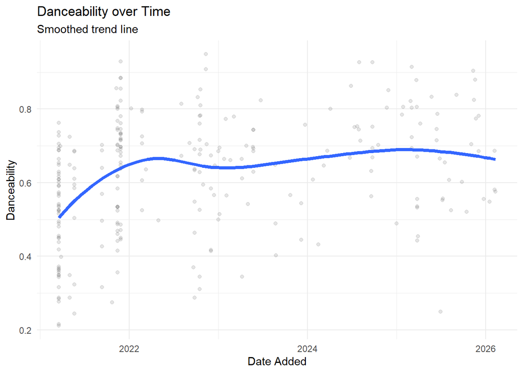

```r
#plot for danceability
library(ggplot2)
LS_short <- readRDS("LS_short.rds")

ggplot(LS_short, aes(x = added_at, y = danceability)) +
  geom_point(alpha = 0.1) +
  geom_smooth(se = FALSE, linewidth = 1.5) +
  labs(title = "Danceability over Time",
       subtitle = "Smoothed trend line",
       x = "Date Added",
       y = "Danceability") +
  theme_minimal()
```

Danceability goes up initially, but stays pretty similar after 2022. However, we can see that there are more individual tracks above the average after 2024.

Perhaps if we were able to use the full Liked Songs list this would also mean that the graph would be trending upward. As most of the songs in my Liked Songs are added after 2024 and are predominately house genres.

### Instrumentalness

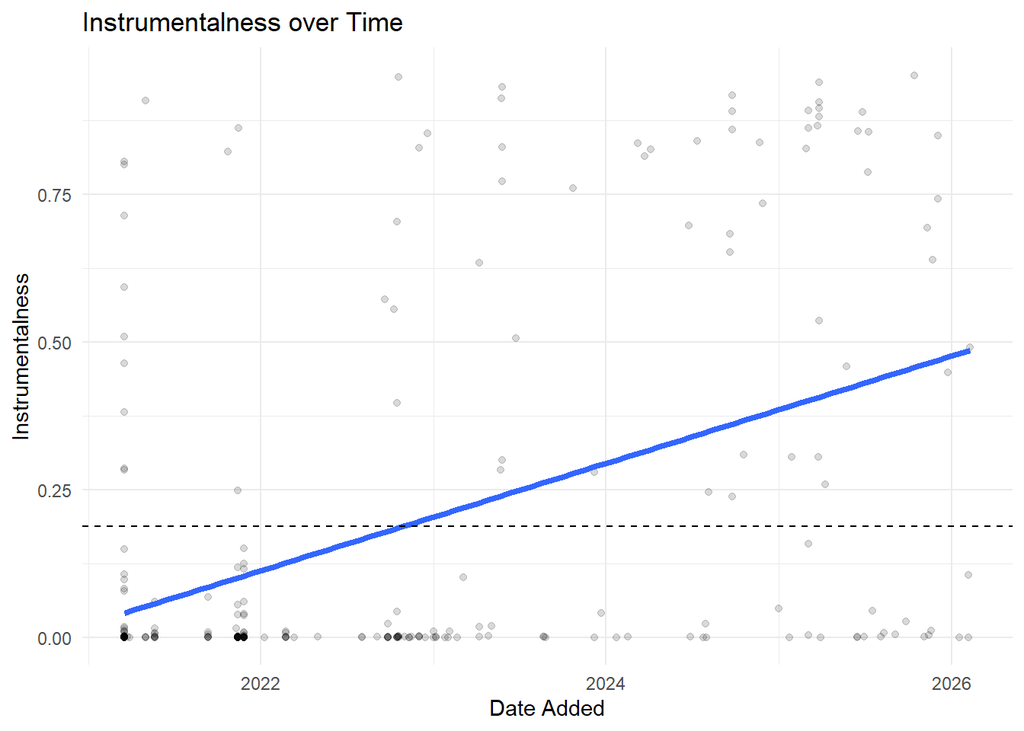

```r
#instrumentalness
library(ggplot2)
LS_short <- readRDS("LS_short.rds")
avg_instr <- mean(LS_short$instrumentalness, na.rm = TRUE)

ggplot(LS_short, aes(x = added_at, y = instrumentalness)) +
  geom_point(alpha = 0.15) +
  geom_smooth(method = "lm", se = FALSE, linewidth = 1.5) +
  geom_hline(yintercept = avg_instr, linetype = "dashed") +
  labs(title = "Instrumentalness over Time",
       x = "Date Added",
       y = "Instrumentalness") +
  theme_minimal()
```

This shows that my liked songs over time, contain less vocal components, and more instruments. Which would correspond with the increase in House and Techno in the last years.

### Populairity

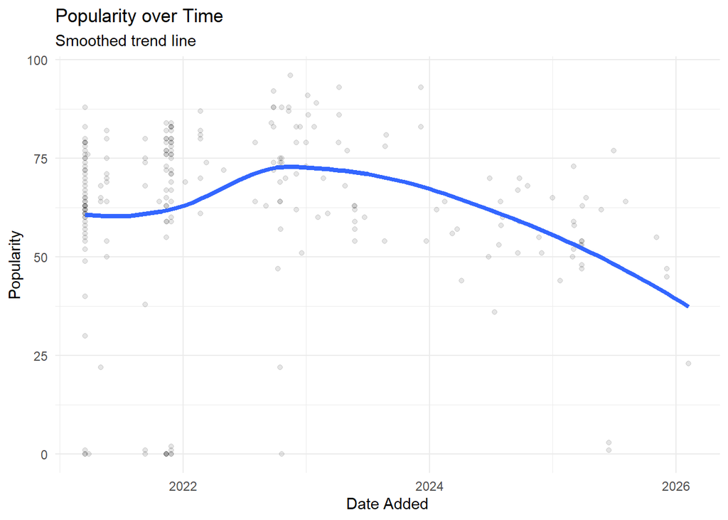

```r
#plot for popularity
library(ggplot2)
LS_short <- readRDS("LS_short.rds")

ggplot(LS_short, aes(x = added_at, y = popularity)) +
  geom_point(alpha = 0.1) +
  geom_smooth(se = FALSE, linewidth = 1.5) +
  labs(title = "Popularity over Time",
       subtitle = "Smoothed trend line",
       x = "Date Added",
       y = "Popularity") +
  theme_minimal()
```

As we see popularity rises (possibly because of Indie/Rock –> 2010’s Pop) and then goes down over time (possibly because of 2010’s Pop –> House genres).

Some notes:

- 26 N/As for popularity (around 10%), mainly in the newly added songs.
  - This could be because newer songs are not yet classified, or that certain unpopular songs don’t get ranked (quick enough)?
- I believe this trend would go down much more if I could fully analyse my Spotify Liked songs over time. As I do believe I have some vague stuff in the newer songs lol. Which would explain why they are not in the teacher’s data frame.

## More analytics, cause who does not want more?

### Matrix (not the movie)

Lets create a matrix to see how these audio characteristics relate to each other.

```r
#plot for matrix
features <- LS_short[, c("energy",
                         "danceability",
                         "valence",
                         "speechiness",
                         "instrumentalness",
                         "acousticness",
                         "popularity")]

cor_matrix <- cor(features, use = "complete.obs")

round(cor_matrix, 2)
```

```
                 energy danceability valence speechiness instrumentalness
energy             1.00        -0.23    0.35       -0.12            -0.18
danceability      -0.23         1.00    0.19        0.14             0.11
valence            0.35         0.19    1.00       -0.03            -0.46
speechiness       -0.12         0.14   -0.03        1.00            -0.01
instrumentalness  -0.18         0.11   -0.46       -0.01             1.00
acousticness      -0.47         0.14   -0.11        0.11            -0.01
popularity        -0.09        -0.03   -0.09        0.02            -0.08
                 acousticness popularity
energy                  -0.47      -0.09
danceability             0.14      -0.03
valence                 -0.11      -0.09
speechiness              0.11       0.02
instrumentalness        -0.01      -0.08
acousticness             1.00       0.04
popularity               0.04       1.00
```

Some notable findings:

- Acousticness and Energy are quite related (-0.47): the more acoustic a song is, the lower the energy.

```
-   Which could correspond with the fact that EDM has less acoustic elements, while generally having higher energy.
```

- Valence and Instrumentalness are related (-0.46): the more instrumental the less “happy” a song is.
  - Which could correspond with that Indie Rock and Minimal (instrumental) Techno are less positive than House music generally.
- Valence and Energy are related (0.35): the more energy a song has, the more happy it is.
  - This shows my data frame has more uplifting dance music than the aggressive rock music.

### Who doesn’t like clusters??

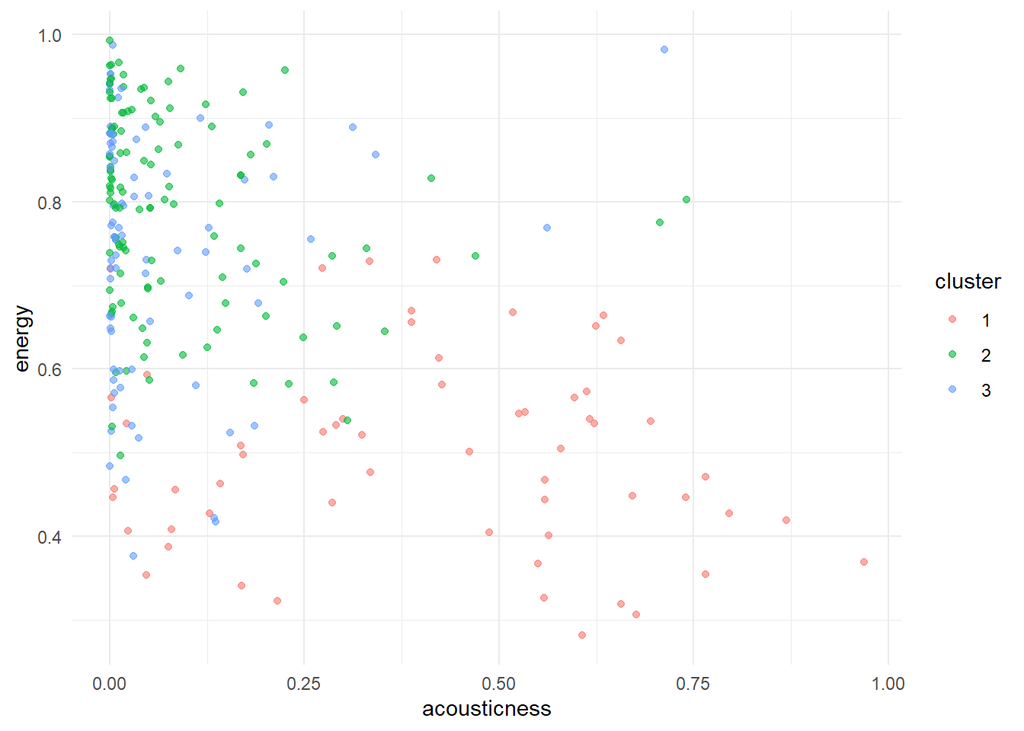

```r
#graph for cluster
#loading packages
library(ggplot2)

#taking only the usable characteristics
features <- LS_short[, c("energy",
                         "danceability",
                         "valence",
                         "speechiness",
                         "instrumentalness",
                         "acousticness")]

#scaling them
features_scaled <- scale(features)

#creating 3 clusters
set.seed(123)
kmeans_result <- kmeans(features_scaled, centers = 3)

#putting the clusters into the dataframe
LS_short$cluster <- as.factor(kmeans_result$cluster)

#plotting the clusters
ggplot(LS_short, aes(x = acousticness,
                     y = energy,
                     color = cluster)) +
  geom_point(alpha = 0.6) +
  theme_minimal()
```

Findings:

- I created three groups in the hope to see the difference in Indie / House / Techno
- What we find in this one graph is indeed the low acoustic (more electronic) songs (House & Techno) clustered together, relative to the presumably Indie music.

## Conclusion

It took some time to get the right data frame data together. Once that was done I could actually start analyzing the data. This led to the conclusion that my music taste did indeed change over time.

Most notable change was instrumentalness going up, which means tracks having less and less vocals. Combined with the fact that the matrix showed that higher instrumentalness relates with lower valence (happiness). Means that my musis taste over time became less vocal and less positive.